# 1 Learning objectives

1. You will learn about conditional execution of code using the `if` statement.
2. You will learn more complex conditional execution of code using the `if/else` statement.

# 2 Conditional statement `if`

An `if` statement allows you to conditionally execute code. To define an `if` statement, we need to define a condition, that’s simple a comparison of values. When comparing values in R, the output is a **BOOLEAN** value. There are two types of boolean values in R, `TRUE`( or `T`), and `FALSE` (or `F`).

We have the following operators to compare values in R, they are known as **relational operators**:

- `==` : Equal to.
- `!=` : Not equal to.
- `<` : Less than. This operator only can be applied with numeric values or dates.
- `>` : Greater than. This operator only can be applied with numeric values or dates.
- `<=` : Less than or equal to. This operator only can be applied with numeric values or dates.
- `>=` : Greater than or equal to. This operator only can be applied with numeric values or dates.

Look at some examples of conditions and your returned values:

- `'example' == 'example'` returns `TRUE`;
- `5 > 6` returns `FALSE`;
- `1 != 1` returns `FALSE`.

The basic structure of an `if` statement looks like:

```r
if (condition) {
  # code executed when condition is TRUE
}
```

If your `if` statement is short and simple, you can structure it like this:

```r
if (condition) # code executed when condition is TRUE
```

Note that the code after the **`if`** statement is executed **only** when the condition is **`TRUE`**.

If you need to get help on the `if` you need to surround it in backticks: `` ?`if` ``.

Here’s a simple example using the `if` statement. It will only display a message if your first name is `"Laure"`.

```r
first_name <- "Laure"

if (first_name == "Laure") {
    message("Hello!")
}
```

or

```r
first_name <- "Laure"

if (first_name == "Laure") message("Hello!")
```

Surely, we could use the `if` to create useful tests or functions for our analyzes.

Sometimes we may want to combine different conditions, in this case, we use the following **logical operators**:

- `!`: This operator return the oposite boolean value of a condition. For example, `5>3` returns `TRUE`, while `!5>3` returns `FALSE`.
- `&&`: This operator can be used to combine two expressions. In this case, the returned value is only `TRUE` when the two conditions are `TRUE`. For example, `(5>3) && (7>3)` return `TRUE`, since the two conditions return `TRUE`, while `(5>3)&&(1>3)` returns `FALSE`, since `1>3` is `FALSE`.
- `&`: The `&&` return just one boolean vale. So, if in the condition we have vectors, the boolean value will be decide according to the first values in each vector. But, if we use the `&` operator, it will compare the values element by element. For example, `c(TRUE, FALSE, FALSE) & c(TRUE, TRUE, FALSE)` returns `TRUE FALSE FALSE`, while `c(TRUE, FALSE, FALSE) && c(TRUE, TRUE, FALSE)` returns `TRUE`.
- `||`: This operator can be used to combine two expressions. In this case, the returned value is `TRUE` when one of the conditions are `TRUE`. For example, `(5>3) || (7>3)` return `TRUE`, since the two conditions return `TRUE`, while `(5>3) || (1>3)` returns `TRUE`, since, at least, `5>3` is `TRUE`.
- `|`: The `||` return just one boolean vale. So, if in the condition we have vectors, the boolean value will be decide according to the first values in each vector. But, if we use the `|` operator, it will be compare the values element by element. For example, `c(TRUE, FALSE, FALSE) | c(TRUE, TRUE, FALSE)` returns `TRUE TRUE FALSE`, while `c(TRUE, FALSE, FALSE) || c(TRUE, TRUE, FALSE)` returns `TRUE`.
- Let `x = runif(n = 1, min = 36.5, max = 42)` be the measure of the body temperature of a patient that arrived at the emergency of your hospital. Look at the four chunks of code below and select the letter referring to the chunk with an `if` statement that returns the message: “The patient has fever”, if the temperature is equal or above 38 degrees Celsius.
- A

```r
x = runif(n = 1, min = 36.5, max = 42)

if (x > 38) {
    message("The patient has fever.")
  }
```

- B

```r
x = runif(n = 1, min = 36.5, max = 42)

if (x = 38) {
    message("The patient has fever.")
  }
```

- C

```r
x = runif(n = 1, min = 36.5, max = 42)

if (x >= 38) {
    message("The patient has fever.")
  }
```

- D

```r
x = runif(n = 1, min = 36.5, max = 42)

if (x <= 38) {
    message("The patient has fever.")
  }
```

```
## Correct! You are terrific!
##   1   2   3
```

```
## Remember that the code after the `if` statement is executed only when the condition is TRUE
```

# 3 Conditional statement `if/else`

In this special case of the `if` statement, there will be a statement `else` that is only executes if the given condition `if` is `FALSE`. It’s basic structure looks like this:

```r
if (condition) {
  # code executed when condition is TRUE
} else {
  # code executed when condition is FALSE
}
```

Note that the code after the **`else`** statement is executed **only** when the condition is **`FALSE`**.

At this point, it will be difficult to understand your code if you structure your `if/else` in a single line, so avoid doing it.

Let’s go back to our previous example and make sure to greet anyone that comes by:

```r
first_name = 'Claire' # Type the first name here

if (first_name == "Laure") {
    message("Hello!")
  } else {
    message("Oh, hi there you too!")
  }
```

You will find that the `if/else` will be very useful to perform two different actions depending on the value of an argument. For instance, the following code will generate two different graphs depending on the type of vector `x`.

When `x` is a vector of strings is returned a bar plot.

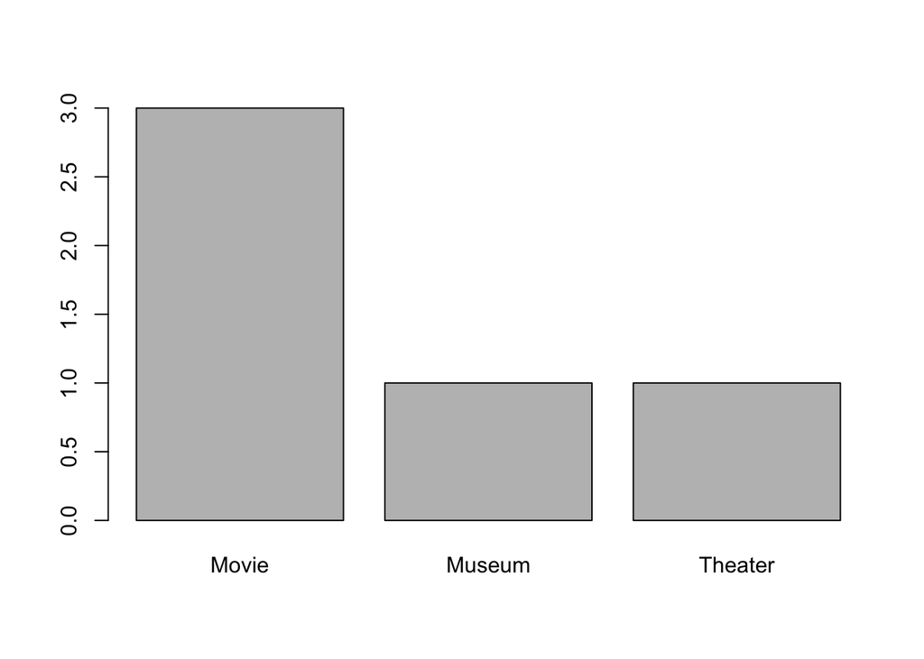

```r
x = c("Movie", "Theater", "Movie", "Movie", "Museum")

if (is.character(x)) {
      barplot(table(x))
    } else {
        hist(x)
    }
```

When `x` is a numeric vector, a histogram is returned.

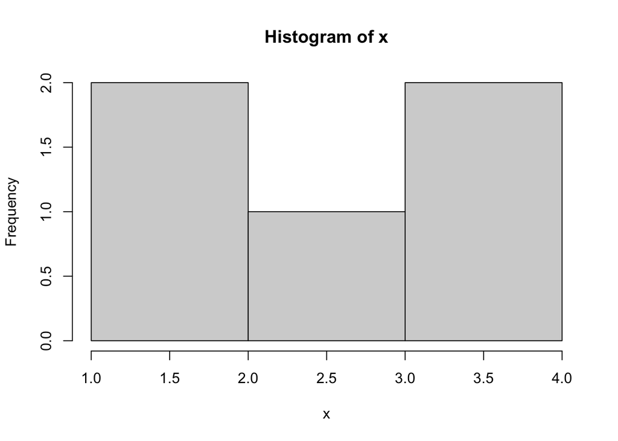

```r
x = c(2, 4, 4, 3, 1)

if (is.character(x)) {
      barplot(table(x))
    } else {
        hist(x)
    }
```

- Let `x = runif(n = 1, min = 18, max = 32)` be the BMI of a patient. Look at the four chunks of code below and select the letter referring to the chunk with an `if/else` statement that returns the message: “Your BMI indicates overweight.”, if the BMI is above 25, and, otherwise, the message: “Your BMI indicates that you are not overweight”.
- A

```r
x = runif(n = 1, min = 18, max = 32)

if (x >= 25){
    message("Your BMI indicates overweight.")
  } else {
    message("Your BMI indicates that you are not overweight")
  }
```

- B

```r
x = runif(n = 1, min = 18, max = 32)

if (x < 25){
    message("Your BMI indicates overweight.")
  } else {
    message("Your BMI indicates that you are not overweight")
  }
```

- C

```r
x = runif(n = 1, min = 18, max = 32)

if (x <= 25){
    message("Your BMI indicates overweight.")
  } else {
    message("Your BMI indicates that you are not overweight")
  }
```

- D

```r
x = runif(n = 1, min = 18, max = 32)

if (x > 25){
    message("Your BMI indicates overweight.")
  } else {
    message("Your BMI indicates that you are not overweight")
  }
```

```
## Correct! You are legendary!
##   1   2   3
```

```
## Remember that the code after the `if` statement is executed only when the condition is TRUE,
## and the code after the `else` statement is executed only when the condition is FALSE.
```

# 4 Conditional statement `if/else if/else`

There is the possibility to use `else if` to add additional conditions. As soon as a condition is `TRUE`, the corresponding block of code is executed. The last block `else` is only executed if none of the conditions are `TRUE`. It’s basic structure looks like this:

```r
if (this) {
  # do that
  } else if (that) {
    # do that
    } else {
      #
    }
```

This way, you can chain multiple `if` statements together:

```r
x = c(TRUE, TRUE, FALSE, TRUE)

if (is.character(x)) {
  barplot(table(x))
} else if (is.numeric(x)) {
    hist(x)
} else {
   message("The type of `x` does not allow a graph!")
}
```

With this, your imagination is your only limit to what you can do with a function. However, avoid having a very long series of chained `if` statements. If this is the case, you should consider rewriting your chain/function.

One thing to pay attention it that only the block of the first true condition is executed. Therefore, **the order of the conditions is extremely important.** In the following example, the second block is never executed and therefore the second message will never be displayed.

```r
x = 50

if (x > 30) {
    message("It is hot outside.")
} else if (x > 40) {
    message("Time to go to the beach!")
} else {
  message("Weather is just fine")
}
```

- Let `x = runif(n = 1, min = 36.5, max = 42)` be the measure of the body temperature of a patient that arrived at the emergency of your hospital. Continuing with our last practice, select the chunk of code with an `if/else if/else` statement that returns a message saying that the patient does not have fever, that the patient has fever if the temperature is equal or above 38 degrees Celsius, and that the patient needs urgent attention if the temperature is equal or above 40 degrees Celsius.
- A

```r
x = runif(n = 1, min = 36.5, max = 42)

if (x >= 38) {
  message('The patient needs urgent attention.')
} else if (x >= 40) {
  message('The patient has fever.')
} else {
    message('The patient does not have fever.')
}
```

- B

```r
x = runif(n = 1, min = 36.5, max = 42)

if (x >= 40) {
  message('The patient needs urgent attention.')
} else if (x >= 38) {
  message('The patient has fever.')
} else {
    message('The patient does not have fever.')
}
```

- C

```r
x = runif(n = 1, min = 36.5, max = 42)

if (x > 40) {
  message('The patient needs urgent attention.')
} else if (x >= 38) {
  message('The patient has fever.')
} else {
    message('The patient does not have fever.')
}
```

- D

```r
x = runif(n = 1, min = 36.5, max = 42)

if (x >= 38) {
  message('The patient needs urgent attention.')
} else if (x > 40) {
  message('The patient has fever.')
} else {
    message('The patient does not have fever.')
}
```

```
## Correct! You are beautiful!
##   1   2   3
```

```
## Remember that the order of the code blocks in an `if/else if/else` statement is important!
```

# Contributors

The following team members contributed to this lesson:

- DANIEL CAMARA  
  Data Scientist at the GRAPH Network and fellowship as Public Health researcher at Fiocruz, Brazil

  Passionate about lots of things, especially when it involves people leading lives with more equality and freedom
- [EDUARDO ARAUJO](https://thegraphcourses.org/members/eduardo_araujo/)  
  Student at Universidade Tecnologica Federal do Parana

  This is a temporary tagline
- [LAURE VANCAUWENBERGHE](https://thegraphcourses.org/members/lolovanco)  
  Data analyst, the GRAPH Network

  A firm believer in science for good, striving to ally programming, health and education.
- [KENE DAVID NWOSU](https://thegraphcourses.org/members/kendavidn/)  
  Data analyst, the GRAPH Network

  Passionate about education.

# References

Some material in this lesson was adapted from the following sources:

- Barnier, Julien. “Introduction à R et au tidyverse.” Accessed May 23, 2022. https://juba.github.io/tidyverse
- Wickham, Hadley; Grolemund, Garrett. “R for Data Science.” Accessed May 25, 2022. https://r4ds.had.co.nz/

This work is licensed under the [Creative Commons Attribution Share Alike](https://creativecommons.org/licenses/by-sa/4.0/) license.

[figure not shown]